# Data Skills-Final Project

Author

2617624

Published

March 28, 2025

# Introduction

## Aims of the Study

This study investigates monthly trends and operational efficiency in ticket management systems through three research questions:

1. How does the number of “received” and “processed” tickets fluctuate over the months?
2. How is the Correlation between “processed” and “received” Tickets?
3. Does the volume of received tickets affect processing efficiency?

The primary goal is to visualize and compare monthly ticket volumes, assess how well processing capacity matches demand, and highlight critical periods where operational performance may falter. This work builds on methodologies from time-series analysis and resource allocation research, adapting them to the context of service management data.

# Methodology & Visualization

## Background and Motivation

Understanding ticket management dynamics is critical for optimizing resource allocation and identifying systemic inefficiencies. Seasonal fluctuations in demand, as seen in sectors like customer service or IT support, often strain processing systems, leading to bottlenecks or underutilized capacity. By analyzing monthly trends, this study addresses how organizations can anticipate demand surges, improve responsiveness, and balance workloads. The dataset’s inclusion of both received and processed tickets for each month provides a dual-axis view of operational performance, making it uniquely suited to explore these questions.

## The dataset

The initial dataset:

```r
library(tidyverse)
knaflic_ticket_trend <- read_csv("datasets/knaflic_ticket_trend.csv")
knaflic_ticket_trend
```

| month | month_num | type | number |
| --- | --- | --- | --- |
| january | 1 | received | 160 |
| january | 1 | processed | 160 |
| february | 2 | received | 184 |
| february | 2 | processed | 184 |
| march | 3 | received | 241 |
| march | 3 | processed | 237 |
| april | 4 | received | 149 |
| april | 4 | processed | 148 |
| may | 5 | received | 180 |
| may | 5 | processed | 181 |

[output cut: 14 more lines]

The analysis of my three research questions utilizes a synthetic dataset containing two key variables:

1. received: Number of tickets submitted monthly
2. processed: Number of tickets resolved monthly

Furthermore, ‘Months’ are encoded numerically (month_num) and labeled with abbreviated names (month.abb) for clarity.

## Research Question One: How does the number of “received” and “processed” tickets fluctuate over the months?

Here is the code:

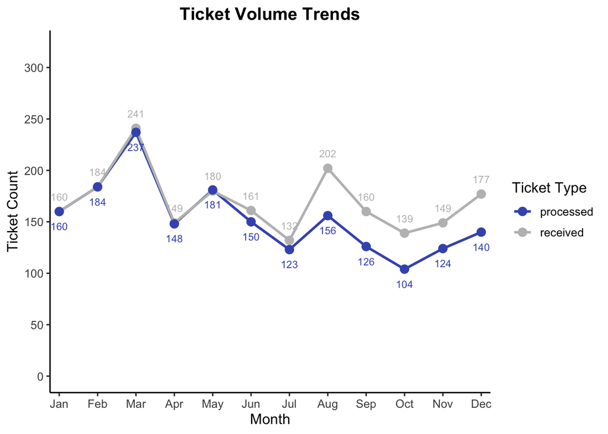

```r
# Corrected code
ggplot(knaflic_ticket_trend, aes(x = month_num, y = number, color = type)) +
  geom_line(linewidth = 1) +
  geom_point(size = 3) +
  geom_text(
    data = filter(knaflic_ticket_trend, type == "processed"),
    aes (label = number),
    vjust = 2.5,
    size = 3,
    show.legend = FALSE
  ) +
  geom_text(
    data = filter(knaflic_ticket_trend, type == "received"),
    aes (label = number),
    vjust = -1.5,
    size = 3,
    show.legend = FALSE
  ) +
  scale_color_manual(values = c("received" = "gray", "processed" = "#4258bd")) +

  # Match lowercase values
  scale_x_continuous(
    breaks = 1:12,
    labels = month.abb,
    expand = c(0.02, 0.02)
  ) +
  scale_y_continuous(
    limits = c(0, 320),
    breaks = seq(0, 300, by = 50)
  ) +
  labs(
    title = "Ticket Volume Trends",
    x = "Month",
    y = "Ticket Count",
    color = "Ticket Type",
  ) +
  theme_classic(base_size = 12) +
  theme(
    plot.title = element_text(face = "bold", hjust = 0.5))
```

## Research Question Two: How is the Correlation between “processed” and “received” Tickets?

This question visualized the relationship between processing and the number of received tickets through scatter plots, supplemented by statistical annotations. This graph uses light blue dots to represent the monthly data (both received and processed), a dark blue dashed line to represent the trend model, and uses the label to illustrate the correlation coefficient: r=0.87.

Here is the code:

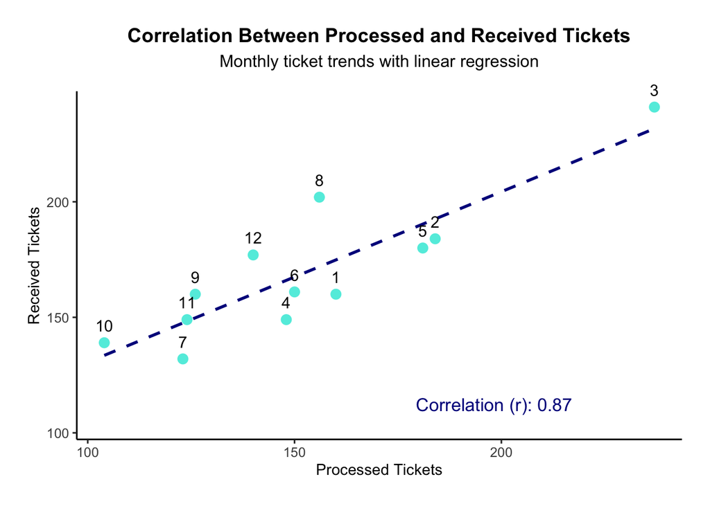

```r
library(tidyverse)
knaflic_ticket_trend <- read_csv("datasets/knaflic_ticket_trend.csv")
# Create wide format and calculate correlation
knaflic_ticket_trend <- knaflic_ticket_trend |>
  pivot_wider(values_from = "number", names_from = "type") |>
  mutate(month = tolower(month))  # Ensure consistent month formatting

correlation <- cor(knaflic_ticket_trend$processed, knaflic_ticket_trend$received) |> round(2)

knaflic_ticket_trend |>
  ggplot(aes(x = processed, y = received)) +
  geom_point(color = "#60ECE0", size = 3) +
  geom_smooth(method = "lm", se = FALSE, linetype = "dashed", color = "darkblue") +
  geom_text(aes(label = month_num), vjust = -1, size = 4) +
  annotate(
    "text",
    x = max(knaflic_ticket_trend$received) - 20, y = min(knaflic_ticket_trend$processed),

    # Bottom-right corner
    label = paste("Correlation (r):", correlation),
    color = "darkblue",
    size = 4.5,
    hjust = 1.1,
    vjust = -1
  ) +
  labs(
    title = "Correlation Between Processed and Received Tickets",
    subtitle = "Monthly ticket trends with linear regression",
    x = "Processed Tickets",
    y = "Received Tickets"
  ) +
  theme_classic(base_size = 12) +
  theme(
    plot.title = element_text(face = "bold", hjust = 0.5, size = 14),
    plot.subtitle = element_text(hjust = 0.5, margin = margin(b = 15)),
    plot.margin = margin(20, 20, 20, 20),
    axis.title = element_text(size = 11),
    axis.text = element_text(color = "grey30")
  ) +
  coord_cartesian(clip = "off")
```

## Research Question Three: How Does Processing Capacity Align with Demand Across Months?

This study evaluates monthly processing capacity alignment through a bar chart, categorizing months into “Overloaded” (orange), “Balanced” (blue), and “Surplus” (green) based on the ratio of processed to received tickets. Thresholds at 85% (overload) and 105% (surplus) are marked with dashed lines and annotated in red to contextualize performance benchmarks.

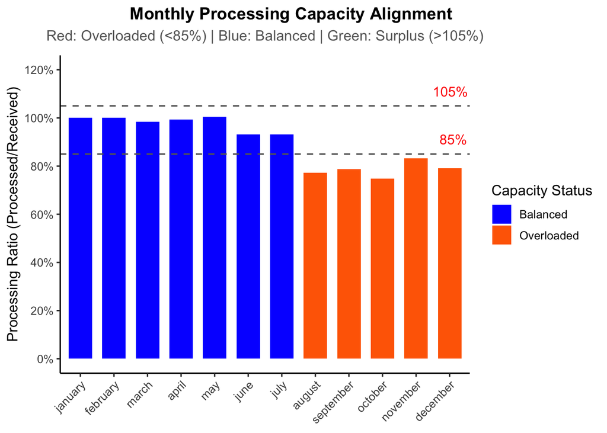

```r
library(tidyverse)

# Data
ticket_data <- tibble(
  month = factor(c("january", "february", "march", "april", "may", "june",
                  "july", "august", "september", "october", "november", "december"),
                levels = tolower(month.name)),
  received = c(160, 184, 241, 149, 180, 161, 132, 202, 160, 139, 149, 177),
  processed = c(160, 184, 237, 148, 181, 150, 123, 156, 126, 104, 124, 140)
)

# Calculate the processing rate and status classification
capacity_analysis <- ticket_data %>%
  mutate(
    processing_ratio = processed / received,
    capacity_status = case_when(
      processing_ratio < 0.85 ~ "Overloaded",
      between(processing_ratio, 0.85, 1.05) ~ "Balanced", # Use "between" make the logic more easier
      processing_ratio > 1.05 ~ "Surplus"
    )
  )

# Visualization
ggplot(capacity_analysis, aes(x = month, y = processing_ratio, fill = capacity_status)) +
  geom_col(width = 0.7) +
  geom_hline(
    yintercept = c(0.85, 1.05),
    linetype = "dashed",
    color = "grey40",
    linewidth = 0.6
  ) +
   annotate(
    "text",
    x = 11.7,
    y = 0.85,
    label = "85%",
    color = "red",
    size = 4,
    hjust = 0,
    vjust = -1
  ) +
  annotate(
    "text",
    x = 11.5,
    y = 1.05,
    label = "105%",
    color = "red",
    size = 4,
    hjust = 0,
    vjust = -1
  ) +
  scale_fill_manual(
    values = c(
      "Overloaded" = "#FF6900",
      "Balanced" = "#0D00FF",
      "Surplus" = "#1a9641")
  ) +
  scale_y_continuous(
    labels = scales::percent_format(accuracy = 1), # Standardized percentage format
    limits = c(0, 1.2),
    breaks = seq(0, 1.2, 0.2)
  ) +
  labs(
    title = "Monthly Processing Capacity Alignment",
    subtitle = "Red: Overloaded (<85%) | Blue: Balanced | Green: Surplus (>105%)",
    x = NULL,
    y = "Processing Ratio (Processed/Received)",
    fill = "Capacity Status"
  ) +
  theme_classic(base_size = 12) +
  theme(
    axis.text.x = element_text(angle = 45, hjust = 1),
    plot.title = element_text(face = "bold", hjust = 0.8, size = 14),
    plot.subtitle = element_text(color = "grey40", hjust = 0.5, margin = margin(b = 10))
  )
```

# Results

## How does the number of received and processed tickets fluctuate over the months?

To conclude, this visualization highlights critical patterns: August shows the largest gap, 202 received and 156 processed, while October reveals persistent inefficiency, which is 139 received vs. 104 processed. If we focus on early months (e.g., January: 160 received vs. 160 processed) demonstrate balanced operations. By combining layered elements (`geom_line`, `geom_point`, and `geom_text`) with a minimalist theme (`theme_classic`), the plot directly answers how ticket volumes fluctuate, the peak and bottom month of both “received’ and”processed”.

## How the Correlation between “processed” and “received” Tickets?

This visualization highlights a strong positive correlation (r = 0.87) between processed and received tickets, indicating that higher demand months generally align with increased processing volumes. Key deviations, such as August (202 received vs. 156 processed) and October (139 received vs. 104 processed), underscore periods where processing lagged despite demand, disrupting the overall trend. The regression line (`geom_smooth`) and annotated correlation coefficient (`annotate`) quantify the relationship, while labeled month numbers (`geom_text`) contextualize outliers. By integrating these elements with a clean theme (`theme_classic`), the plot directly answers how processing efficiency correlates with demand, revealing both consistent scaling and seasonal bottlenecks.

# Conclusion